# Quick Project 2 TA

Joey Clancy

# 1 Project Goal

The goal for this analysis is to determine whether the Houston Rocket’s offensive strategy is a valid method to improving win percentage. Houston is the only team in the NBA that is fully embracing Mike D’Antoni’s fast paced, high shooting volume offense, and it seems to be having a lot of success. This project provides an in depth analysis on which scoring statistics positively and negatively impact winning, so that other teams may take and adapt this strategy to suit their personnel.

# 2 Setup and Preprocessing

## 2.1 Import packages

```r
library(ggplot2)
library(dplyr)
library(patchwork)
library(kableExtra)
library(plotly)
library(stringr)
library(RColorBrewer)
library(forcats)
```

## 2.2 Import datasets

```r
teamStat <- read.csv("teamStat.csv") # TEAM STATS
opponentStat <- read.csv("opponStat.csv") # Only used for join
winLoss <- read.csv("winLoss.csv") # Only used for join
```

## 2.3 Rename columns

```r
names(opponentStat)[names(opponentStat)=="PTS"] <- "PTS_ALLOWED"
names(teamStat)[names(teamStat)=="PTS"] <- "PTS_FOR"
```

## 2.4 Reorder and join columns from data

```r
# Reorder data so that cbind function will work correctly
teamStat <- teamStat[order(teamStat$Team),]
opponentStat <- opponentStat[order(opponentStat$Team),]
winLoss <- winLoss[order(winLoss$Team),]

# Join the points allowed column to teamStat data
teamStat <- cbind(teamStat, PTS_ALLOWED = opponentStat$PTS_ALLOWED)
# Join Win and Losses column to teamStat data
teamStat <- cbind(teamStat, W = winLoss$W)
teamStat <- cbind(teamStat, L = winLoss$L)
teamStat <- cbind(teamStat, Pace = winLoss$Pace)

# Reorder by Wins
teamStat <- arrange(teamStat, -W)
```

## 2.5 Convert variables to factors

```r
# Convert necessary variables to factors
teamStat$Team <- as.factor(teamStat$Team)
teamStat$Year <- as.factor(teamStat$Year)
```

## 2.6 Add columns

```r
# Add Playoffs variable
teamStat$Playoffs = grepl("\\*", teamStat$Team)

# Add pythagorean expectation column
# Output is the EXPECTED win to loss ratio for each team (i.e. 0.75 = 75% win percentage)
teamStat$PYTHAG_WIN <- teamStat$PTS_FOR ^ 13.91 / (teamStat$PTS_FOR ^ 13.91 + teamStat$PTS_ALLOWED ^ 13.91)

# Add the ACTUAL win-loss ratio
teamStat$WIN_PERCENTAGE <- teamStat$W / (teamStat$W + teamStat$L)

# Add effective field goal percentage for teamStat
teamStat$eFG. <- (teamStat$FG + (0.5 * teamStat$X3P)) / teamStat$FGA

# Add 3PAr variable
teamStat$X3PAr <- teamStat$X3PA / teamStat$FGA
```

# 3 Univariate non-graphical analysis

```r
head(teamStat)
```

```
##   Year                   Team  G    MP   FG  FGA   FG.  X3P X3PA  X3P.  X2P
## 1 2016 Golden State Warriors* 82 19880 3489 7159 0.487 1077 2592 0.416 2412
## 2 2017 Golden State Warriors* 82 19780 3532 7140 0.495  982 2562 0.383 2550
## 3 2015 Golden State Warriors* 82 19730 3410 7137 0.478  883 2217 0.398 2527
## 4 2016     San Antonio Spurs* 82 19705 3289 6797 0.484  570 1518 0.375 2719
## 5 2013            Miami Heat* 82 19880 3148 6348 0.496  717 1809 0.396 2431
## 6 2018       Houston Rockets* 82 19755 3174 6906 0.460 1256 3470 0.362 1918
##   X2PA  X2P.   FT  FTA   FT. ORB  DRB  TRB  AST STL BLK  TOV   PF PTS_FOR
## 1 4567 0.528 1366 1790 0.763 816 2972 3788 2373 689 498 1245 1701    9421
## 2 4578 0.557 1457 1850 0.788 770 2873 3643 2491 785 555 1211 1585    9503
## 3 4920 0.514 1313 1709 0.768 853 2814 3667 2248 762 496 1185 1628    9016
## 4 5279 0.515 1342 1672 0.803 770 2831 3601 2010 677 485 1071 1433    8490
## 5 4539 0.536 1423 1887 0.754 676 2490 3166 1890 710 441 1143 1533    8436
## 6 3436 0.558 1609 2061 0.781 739 2825 3564 1767 699 392 1135 1597    9213
##   PTS_ALLOWED  W  L Pace Playoffs PYTHAG_WIN WIN_PERCENTAGE      eFG.     X3PAr
## 1        8539 73  9 99.3     TRUE  0.7969462      0.8902439 0.5625786 0.3620617
## 2        8549 67 15 99.8     TRUE  0.8132980      0.8170732 0.5634454 0.3588235
## 3        8188 67 15 98.3     TRUE  0.7924843      0.8170732 0.5396525 0.3106347
## 4        7618 67 15 93.8     TRUE  0.8186901      0.8170732 0.5258202 0.2233338
## 5        7791 66 16 90.7     TRUE  0.7514551      0.8048780 0.5523787 0.2849716
## 6        8518 65 17 97.6     TRUE  0.7485731      0.7926829 0.5505358 0.5024616
```

**Comments**

X3P = Number of three pointers made in that year

X3PA = Number of three pointers attempted in that year

X3P. = Three point percentage

X2P, X2PA, and X2P. have same definitions but for two point shots

```r
str(teamStat)
```

```
## 'data.frame':    300 obs. of  34 variables:
##  $ Year          : Factor w/ 10 levels "2010","2011",..: 7 8 6 7 4 9 2 5 1 8 ...
##  $ Team          : Factor w/ 63 levels "Atlanta Hawks",..: 22 22 22 57 34 24 12 57 14 57 ...
##  $ G             : int  82 82 82 82 82 82 82 82 82 82 ...
##  $ MP            : int  19880 19780 19730 19705 19880 19755 19830 19755 19780 19805 ...
##  $ FG            : int  3489 3532 3410 3289 3148 3174 3042 3326 3101 3222 ...
##  $ FGA           : int  7159 7140 7137 6797 6348 6906 6587 6844 6391 6864 ...
##  $ FG.           : num  0.487 0.495 0.478 0.484 0.496 0.46 0.462 0.486 0.485 0.469 ...
##  $ X3P           : int  1077 982 883 570 717 1256 511 698 602 753 ...
##  $ X3PA          : int  2592 2562 2217 1518 1809 3470 1415 1757 1582 1927 ...
##  $ X3P.          : num  0.416 0.383 0.398 0.375 0.396 0.362 0.361 0.397 0.381 0.391 ...
##  $ X2P           : int  2412 2550 2527 2719 2431 1918 2531 2628 2499 2469 ...
##  $ X2PA          : int  4567 4578 4920 5279 4539 3436 5172 5087 4809 4937 ...
##  $ X2P.          : num  0.528 0.557 0.514 0.515 0.536 0.558 0.489 0.517 0.52 0.5 ...
##  $ FT            : int  1366 1457 1313 1342 1423 1609 1492 1289 1569 1440 ...
```

[output cut: 20 more lines]

```r
summary(teamStat)
```

```
##       Year                         Team           G               MP
##  2010   : 30   Sacramento Kings      : 10   Min.   :66.00   Min.   :15840
##  2011   : 30   San Antonio Spurs*    : 10   1st Qu.:82.00   1st Qu.:19755
##  2012   : 30   Boston Celtics*       :  9   Median :82.00   Median :19805
##  2013   : 30   Minnesota Timberwolves:  9   Mean   :80.39   Mean   :19437
##  2014   : 30   Oklahoma City Thunder*:  9   3rd Qu.:82.00   3rd Qu.:19855
##  2015   : 30   Phoenix Suns          :  9   Max.   :82.00   Max.   :20055
##  (Other):120   (Other)               :244
##        FG            FGA            FG.              X3P              X3PA
##  Min.   :2193   Min.   :5086   Min.   :0.4080   Min.   : 259.0   Min.   : 777
##  1st Qu.:3000   1st Qu.:6638   1st Qu.:0.4440   1st Qu.: 507.8   1st Qu.:1463
##  Median :3124   Median :6844   Median :0.4540   Median : 660.0   Median :1838
##  Mean   :3072   Mean   :6742   Mean   :0.4555   Mean   : 662.7   Mean   :1861
##  3rd Qu.:3212   3rd Qu.:7052   3rd Qu.:0.4652   3rd Qu.: 806.2   3rd Qu.:2198
##  Max.   :3612   Max.   :7706   Max.   :0.5030   Max.   :1323.0   Max.   :3721
##
##       X3P.             X2P            X2PA           X2P.              FT
##  Min.   :0.2950   Min.   :1605   Min.   :3377   Min.   :0.4390   Min.   : 889
##  1st Qu.:0.3430   1st Qu.:2303   1st Qu.:4574   1st Qu.:0.4788   1st Qu.:1311
##  Median :0.3540   Median :2447   Median :4940   Median :0.4920   Median :1423
##  Mean   :0.3549   Mean   :2409   Mean   :4881   Mean   :0.4942   Mean   :1413
##  3rd Qu.:0.3670   3rd Qu.:2540   3rd Qu.:5201   3rd Qu.:0.5082   3rd Qu.:1520
##  Max.   :0.4160   Max.   :2891   Max.   :5875   Max.   :0.5650   Max.   :1977
##
##       FTA            FT.              ORB              DRB            TRB
##  Min.   :1198   Min.   :0.6600   Min.   : 509.0   Min.   :1879   Min.   :2560
##  1st Qu.:1716   1st Qu.:0.7450   1st Qu.: 781.5   1st Qu.:2477   1st Qu.:3355
##  Median :1870   Median :0.7610   Median : 858.0   Median :2628   Median :3507
##  Mean   :1860   Mean   :0.7601   Mean   : 857.7   Mean   :2596   Mean   :3454
##  3rd Qu.:2000   3rd Qu.:0.7800   3rd Qu.: 937.0   3rd Qu.:2774   3rd Qu.:3630
##  Max.   :2549   Max.   :0.8280   Max.   :1196.0   Max.   :3316   Max.   :4078
##
##       AST            STL             BLK             TOV             PF
##  Min.   :1224   Min.   :390.0   Min.   :195.0   Min.   : 738   Min.   :1109
##  1st Qu.:1689   1st Qu.:564.0   1st Qu.:347.0   1st Qu.:1093   1st Qu.:1558
##  Median :1796   Median :615.0   Median :387.5   Median :1152   Median :1654
##  Mean   :1792   Mean   :613.7   Mean   :393.0   Mean   :1152   Mean   :1632
##  3rd Qu.:1917   3rd Qu.:670.2   3rd Qu.:436.0   3rd Qu.:1223   3rd Qu.:1737
##  Max.   :2491   Max.   :821.0   Max.   :624.0   Max.   :1453   Max.   :2030
##
```

[output cut: 9 more lines]

```
##  Mode :logical   Min.   :0.1126   Min.   :0.1061   Min.   :0.4392
##  FALSE:140       1st Qu.:0.3872   1st Qu.:0.3786   1st Qu.:0.4892
##  TRUE :160       Median :0.5089   Median :0.5122   Median :0.5029
##                  Mean   :0.5008   Mean   :0.5000   Mean   :0.5042
##                  3rd Qu.:0.6171   3rd Qu.:0.6098   3rd Qu.:0.5196
##                  Max.   :0.8187   Max.   :0.8902   Max.   :0.5690
##
##      X3PAr
##  Min.   :0.1362
##  1st Qu.:0.2233
##  Median :0.2692
##  Mean   :0.2737
##  3rd Qu.:0.3195
##  Max.   :0.5195
##
```

# 4 Univariate Graphical Analysis

## 4.1 Numeric Variables

**Function for histogram-boxplot combination**

```r
# Creating a function to plot histogram and box plot at the same time
histPlusBox <- function(data, vbl) {
  histogram <- ggplot(data = data, mapping = aes(x = {{ vbl }})) +
    geom_histogram(bins = 30)

  boxplot <- ggplot(data = data, mapping = aes(x = 0)) +
    geom_boxplot(mapping = aes(y = {{ vbl }})) +
    coord_flip()

  histogram / boxplot
}
```

### 4.1.1 Pace

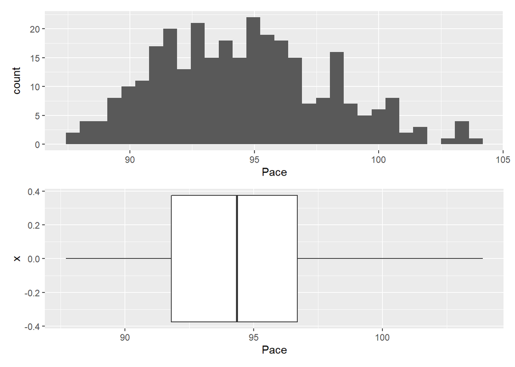

```r
histPlusBox(teamStat, Pace)
```

### 4.1.2 Actual Team Winning %

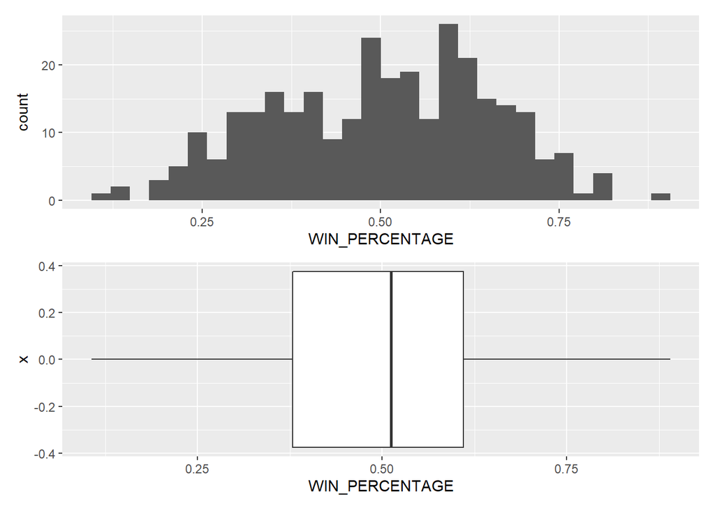

```r
histPlusBox(teamStat, WIN_PERCENTAGE)
```

### 4.1.3 Predicted Team Winning %

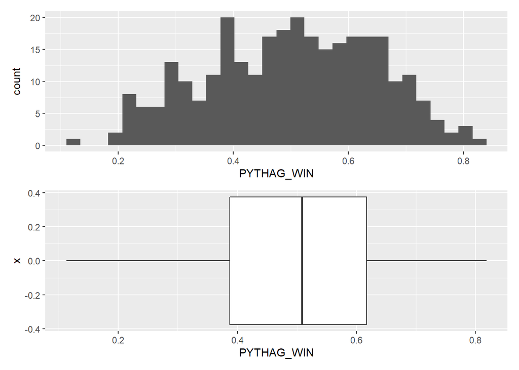

```r
histPlusBox(teamStat, PYTHAG_WIN)
```

### 4.1.4 Wins

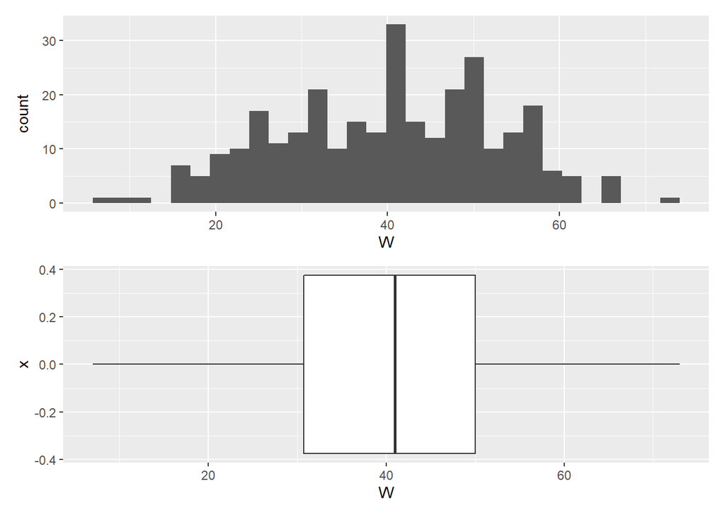

```r
histPlusBox(teamStat, W)
```

### 4.1.5 Losses

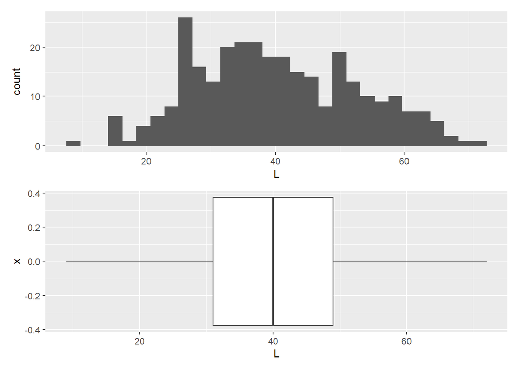

```r
histPlusBox(teamStat, L)
```

### 4.1.6 2P Made Per Team

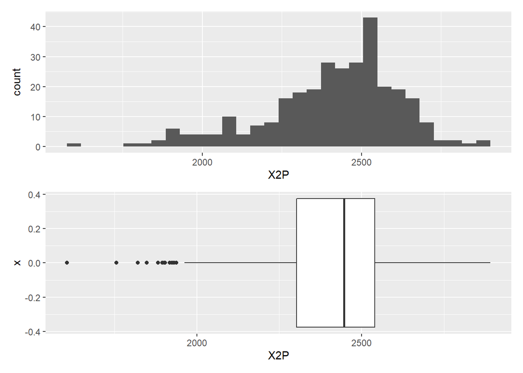

```r
histPlusBox(teamStat, X2P)
```

### 4.1.7 2P Attempted Per Team

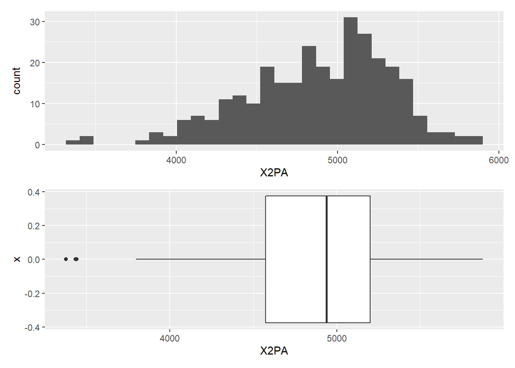

```r
histPlusBox(teamStat, X2PA)
```

### 4.1.8 2P Percentage Per Team

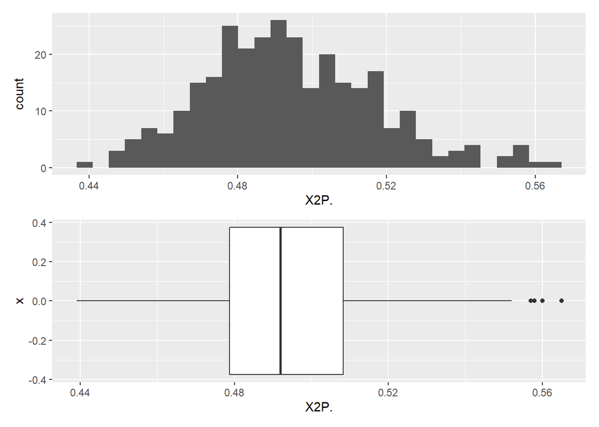

```r
histPlusBox(teamStat, X2P.)
```

### 4.1.9 3P Made Per Team

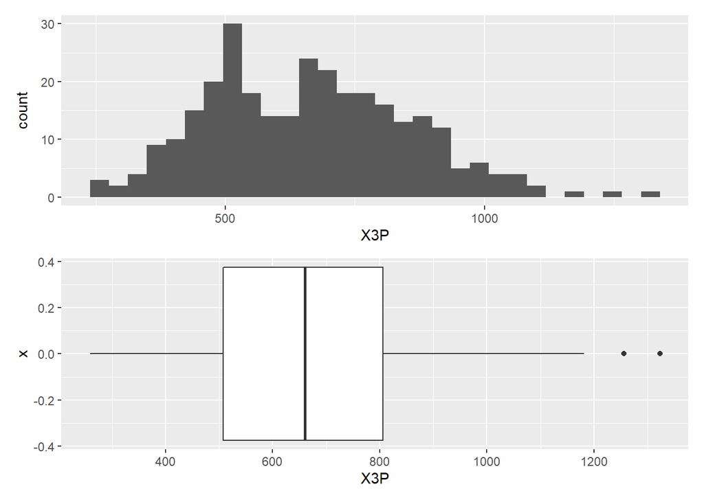

```r
histPlusBox(teamStat, X3P)
```

### 4.1.10 3P Attempted Per Team

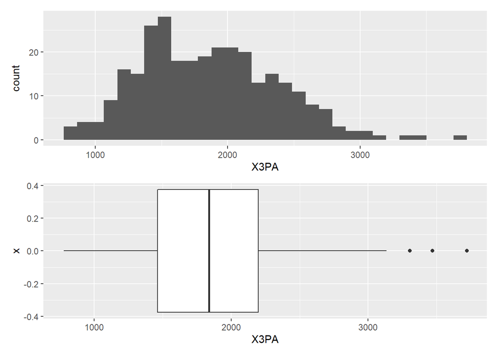

```r
histPlusBox(teamStat, X3PA)
```

### 4.1.11 3P Percentage Per Team

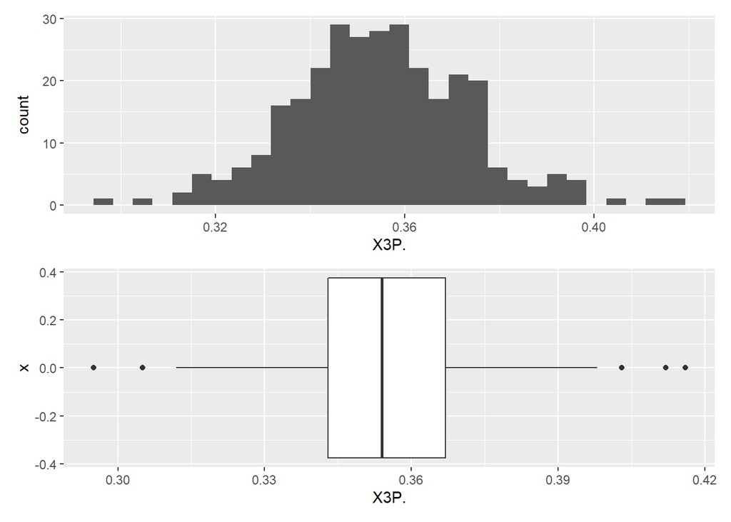

```r
histPlusBox(teamStat, X3P.)
```

### 4.1.12 Field Goals Attempted Per Team

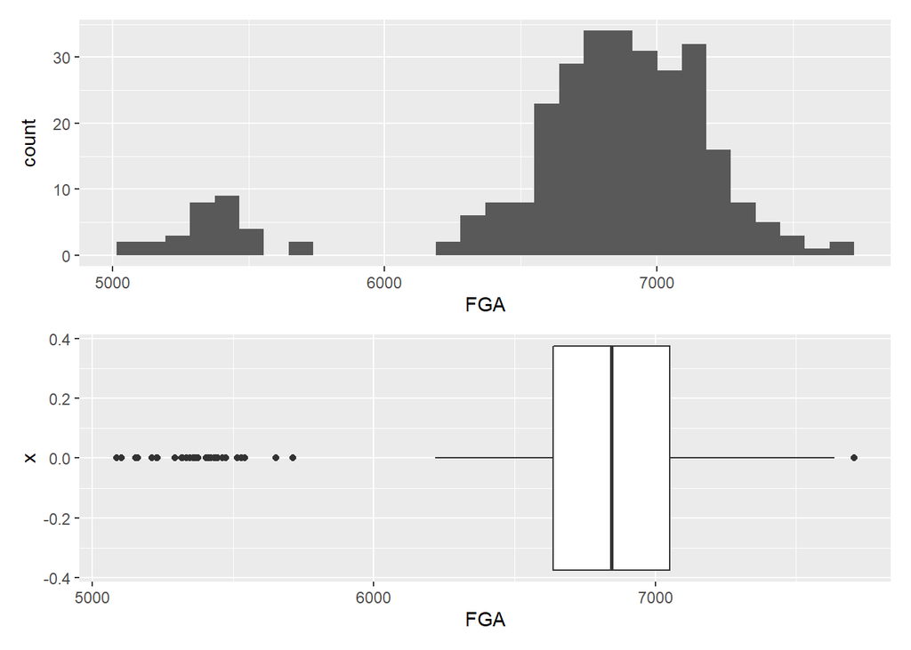

```r
histPlusBox(teamStat, FGA)
```

### 4.1.13 Field Goals Made Per Team

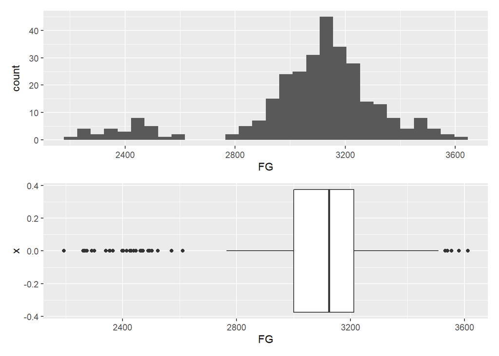

```r
histPlusBox(teamStat, FG)
```

### 4.1.14 Team Effective Field Goal %

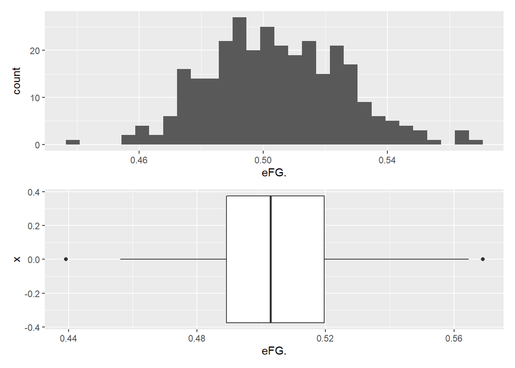

```r
histPlusBox(teamStat, eFG.)
```

### 4.1.15 FT Made Per Team

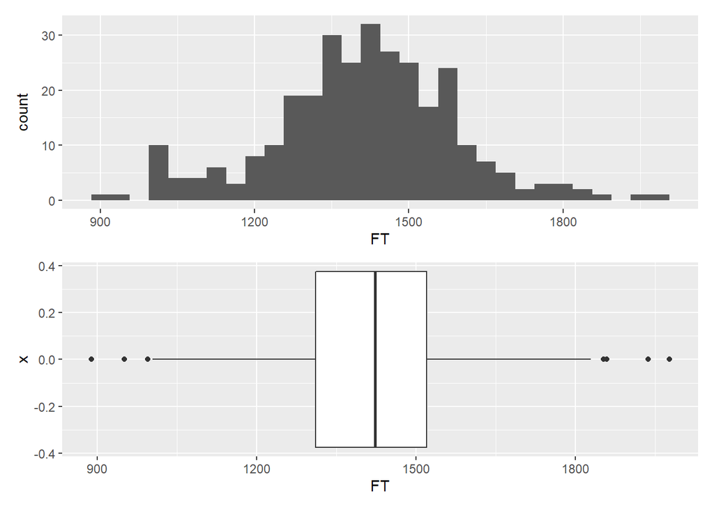

```r
histPlusBox(teamStat, FT)
```

### 4.1.16 FT Attempted Per Team

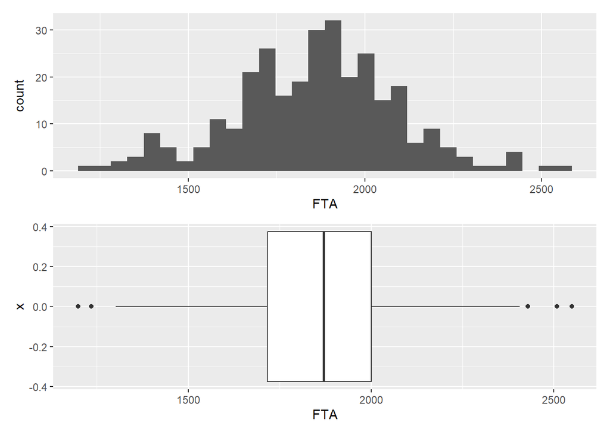

```r
histPlusBox(teamStat, FTA)
```

### 4.1.17 FT Percentage Per Team

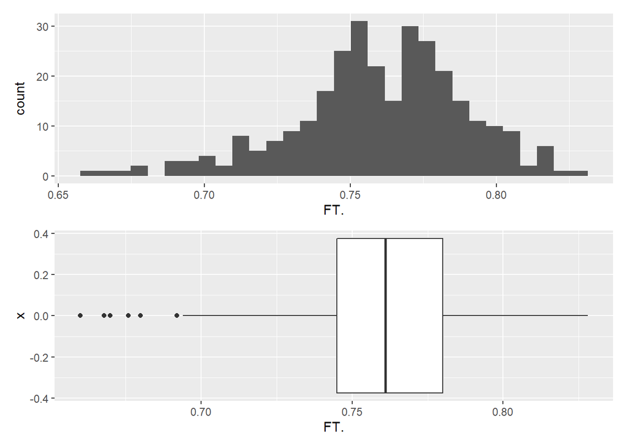

```r
histPlusBox(teamStat, FT.)
```

**Initial Questions**

- Impact of 3P shooting on actual wins and predicted wins?
  - Compare to impact of 2P shooting
- Effective field goal percentage impact on winning ratios?
- What scoring category most impacts winning?
- Do attempted shots impact team performance?

# 5 Multivariate Non-graphical Analysis

## 5.1 Numerical

### 5.1.1 Correlation Table for Team Stats

```r
# Correlation table of quantitative variables
corTab <- teamStat %>%
  select_if(is.numeric) %>% # Use to select just the numeric variables
  cor() %>%
  round(2)
kable(corTab)
```

|  | G | MP | FG | FGA | FG. | X3P | X3PA | X3P. | X2P | X2PA | X2P. | FT | FTA | FT. | ORB | DRB | TRB | AST | STL | BLK | TOV | PF | PTS_FOR | PTS_ALLOWED | W | L | Pace | PYTHAG_WIN | WIN_PERCENTAGE | … |
| --- | --- | --- | --- | --- | --- | --- | --- | --- | --- | --- | --- | --- | --- | --- | --- | --- | --- | --- | --- | --- | --- | --- | --- | --- | --- | --- | --- | --- | --- | --- |
| G | 1.00 | 1.00 | 0.83 | 0.87 | 0.16 | 0.41 | 0.42 | 0.14 | 0.67 | 0.54 | 0.25 | 0.56 | 0.55 | 0.08 | 0.34 | 0.76 | 0.80 | 0.64 | 0.46 | 0.30 | 0.59 | 0.71 | 0.81 | 0.82 | 0.19 | 0.19 | 0.32 | -0.01 | 0.00 | … |
| MP | 1.00 | 1.00 | 0.82 | 0.87 | 0.16 | 0.40 | 0.41 | 0.14 | 0.68 | 0.55 | 0.24 | 0.56 | 0.55 | 0.09 | 0.34 | 0.76 | 0.80 | 0.64 | 0.46 | 0.30 | 0.59 | 0.71 | 0.81 | 0.81 | 0.19 | 0.19 | 0.31 | 0.00 | 0.00 | … |
| FG | 0.83 | 0.82 | 1.00 | 0.92 | 0.48 | 0.63 | 0.61 | 0.31 | 0.70 | 0.38 | 0.60 | 0.45 | 0.41 | 0.16 | 0.21 | 0.85 | 0.83 | 0.83 | 0.51 | 0.33 | 0.46 | 0.59 | 0.96 | 0.87 | 0.35 | -0.04 | 0.66 | 0.20 | 0.20 | … |
| FGA | 0.87 | 0.87 | 0.92 | 1.00 | 0.10 | 0.61 | 0.63 | 0.10 | 0.61 | 0.44 | 0.32 | 0.41 | 0.39 | 0.10 | 0.36 | 0.85 | 0.88 | 0.72 | 0.46 | 0.24 | 0.49 | 0.64 | 0.90 | 0.93 | 0.11 | 0.22 | 0.67 | -0.06 | -0.06 | … |
| FG. | 0.16 | 0.16 | 0.48 | 0.10 | 1.00 | 0.21 | 0.12 | 0.57 | 0.41 | -0.02 | 0.81 | 0.23 | 0.18 | 0.17 | -0.28 | 0.26 | 0.12 | 0.51 | 0.26 | 0.29 | 0.07 | 0.06 | 0.44 | 0.13 | 0.66 | -0.60 | 0.18 | 0.64 | 0.64 | … |
| X3P | 0.41 | 0.40 | 0.63 | 0.61 | 0.21 | 1.00 | 0.99 | 0.40 | -0.12 | -0.42 | 0.64 | 0.17 | 0.15 | 0.11 | -0.16 | 0.69 | 0.55 | 0.60 | 0.28 | 0.10 | 0.20 | 0.26 | 0.73 | 0.61 | 0.32 | -0.17 | 0.71 | 0.25 | 0.25 | … |
| X3PA | 0.42 | 0.41 | 0.61 | 0.63 | 0.12 | 0.99 | 1.00 | 0.25 | -0.13 | -0.42 | 0.60 | 0.18 | 0.17 | 0.08 | -0.12 | 0.69 | 0.56 | 0.56 | 0.29 | 0.08 | 0.23 | 0.28 | 0.72 | 0.63 | 0.24 | -0.08 | 0.74 | 0.17 | 0.16 | … |
| X3P. | 0.14 | 0.14 | 0.31 | 0.10 | 0.57 | 0.40 | 0.25 | 1.00 | 0.03 | -0.17 | 0.38 | 0.03 | -0.05 | 0.23 | -0.28 | 0.24 | 0.11 | 0.37 | 0.07 | 0.13 | -0.05 | -0.01 | 0.33 | 0.06 | 0.55 | -0.50 | 0.09 | 0.53 | 0.54 | … |
| X2P | 0.67 | 0.68 | 0.70 | 0.61 | 0.41 | -0.12 | -0.13 | 0.03 | 1.00 | 0.87 | 0.18 | 0.41 | 0.39 | 0.10 | 0.41 | 0.45 | 0.55 | 0.51 | 0.39 | 0.32 | 0.40 | 0.51 | 0.55 | 0.55 | 0.15 | 0.11 | 0.19 | 0.01 | 0.02 | … |
| X2PA | 0.54 | 0.55 | 0.38 | 0.44 | -0.02 | -0.42 | -0.42 | -0.17 | 0.87 | 1.00 | -0.33 | 0.27 | 0.27 | 0.03 | 0.56 | 0.20 | 0.39 | 0.19 | 0.21 | 0.19 | 0.31 | 0.43 | 0.22 | 0.35 | -0.15 | 0.36 | -0.07 | -0.27 | -0.25 | … |
| X2P. | 0.25 | 0.24 | 0.60 | 0.32 | 0.81 | 0.64 | 0.60 | 0.38 | 0.18 | -0.33 | 1.00 | 0.27 | 0.24 | 0.13 | -0.31 | 0.48 | 0.31 | 0.62 | 0.34 | 0.25 | 0.15 | 0.14 | 0.64 | 0.37 | 0.59 | -0.50 | 0.52 | 0.56 | 0.55 | … |
| FT | 0.56 | 0.56 | 0.45 | 0.41 | 0.23 | 0.17 | 0.18 | 0.03 | 0.41 | 0.27 | 0.27 | 1.00 | 0.95 | 0.23 | 0.30 | 0.43 | 0.49 | 0.25 | 0.26 | 0.26 | 0.41 | 0.54 | 0.59 | 0.50 | 0.28 | -0.07 | 0.25 | 0.19 | 0.18 | … |
| FTA | 0.55 | 0.55 | 0.41 | 0.39 | 0.18 | 0.15 | 0.17 | -0.05 | 0.39 | 0.27 | 0.24 | 0.95 | 1.00 | -0.08 | 0.39 | 0.40 | 0.50 | 0.22 | 0.28 | 0.25 | 0.47 | 0.55 | 0.55 | 0.48 | 0.23 | -0.02 | 0.24 | 0.14 | 0.13 | … |
| FT. | 0.08 | 0.09 | 0.16 | 0.10 | 0.17 | 0.11 | 0.08 | 0.23 | 0.10 | 0.03 | 0.13 | 0.23 | -0.08 | 1.00 | -0.25 | 0.13 | 0.02 | 0.15 | -0.04 | 0.09 | -0.16 | 0.02 | 0.20 | 0.11 | 0.18 | -0.15 | 0.08 | 0.16 | 0.17 | … |
| ORB | 0.34 | 0.34 | 0.21 | 0.36 | -0.28 | -0.16 | -0.12 | -0.28 | 0.41 | 0.56 | -0.31 | 0.30 | 0.39 | -0.25 | 1.00 | 0.11 | 0.48 | -0.01 | 0.11 | 0.13 | 0.35 | 0.38 | 0.18 | 0.24 | -0.08 | 0.21 | -0.04 | -0.13 | -0.14 | … |
| DRB | 0.76 | 0.76 | 0.85 | 0.85 | 0.26 | 0.69 | 0.69 | 0.24 | 0.45 | 0.20 | 0.48 | 0.43 | 0.40 | 0.13 | 0.11 | 1.00 | 0.93 | 0.72 | 0.29 | 0.36 | 0.45 | 0.45 | 0.87 | 0.76 | 0.37 | -0.08 | 0.66 | 0.23 | 0.23 | … |
| TRB | 0.80 | 0.80 | 0.83 | 0.88 | 0.12 | 0.55 | 0.56 | 0.11 | 0.55 | 0.39 | 0.31 | 0.49 | 0.50 | 0.02 | 0.48 | 0.93 | 1.00 | 0.63 | 0.30 | 0.37 | 0.53 | 0.54 | 0.83 | 0.76 | 0.29 | 0.01 | 0.57 | 0.16 | 0.15 | … |
| AST | 0.64 | 0.64 | 0.83 | 0.72 | 0.51 | 0.60 | 0.56 | 0.37 | 0.51 | 0.19 | 0.62 | 0.25 | 0.22 | 0.15 | -0.01 | 0.72 | 0.63 | 1.00 | 0.48 | 0.33 | 0.41 | 0.39 | 0.79 | 0.66 | 0.39 | -0.14 | 0.59 | 0.26 | 0.27 | … |
| STL | 0.46 | 0.46 | 0.51 | 0.46 | 0.26 | 0.28 | 0.29 | 0.07 | 0.39 | 0.21 | 0.34 | 0.26 | 0.28 | -0.04 | 0.11 | 0.29 | 0.30 | 0.48 | 1.00 | 0.24 | 0.42 | 0.45 | 0.49 | 0.40 | 0.25 | -0.08 | 0.35 | 0.18 | 0.17 | … |
| BLK | 0.30 | 0.30 | 0.33 | 0.24 | 0.29 | 0.10 | 0.08 | 0.13 | 0.32 | 0.19 | 0.25 | 0.26 | 0.25 | 0.09 | 0.13 | 0.36 | 0.37 | 0.33 | 0.24 | 1.00 | 0.30 | 0.23 | 0.32 | 0.17 | 0.35 | -0.23 | 0.15 | 0.30 | 0.29 | … |
| TOV | 0.59 | 0.59 | 0.46 | 0.49 | 0.07 | 0.20 | 0.23 | -0.05 | 0.40 | 0.31 | 0.15 | 0.41 | 0.47 | -0.16 | 0.35 | 0.45 | 0.53 | 0.41 | 0.42 | 0.30 | 1.00 | 0.64 | 0.47 | 0.57 | -0.10 | 0.32 | 0.38 | -0.21 | -0.21 | … |
| PF | 0.71 | 0.71 | 0.59 | 0.64 | 0.06 | 0.26 | 0.28 | -0.01 | 0.51 | 0.43 | 0.14 | 0.54 | 0.55 | 0.02 | 0.38 | 0.45 | 0.54 | 0.39 | 0.45 | 0.23 | 0.64 | 1.00 | 0.60 | 0.68 | -0.03 | 0.30 | 0.34 | -0.16 | -0.17 | … |
| PTS_FOR | 0.81 | 0.81 | 0.96 | 0.90 | 0.44 | 0.73 | 0.72 | 0.33 | 0.55 | 0.22 | 0.64 | 0.59 | 0.55 | 0.20 | 0.18 | 0.87 | 0.83 | 0.79 | 0.49 | 0.32 | 0.47 | 0.60 | 1.00 | 0.88 | 0.39 | -0.08 | 0.70 | 0.25 | 0.24 | … |
| PTS_ALLOWED | 0.82 | 0.81 | 0.87 | 0.93 | 0.13 | 0.61 | 0.63 | 0.06 | 0.55 | 0.35 | 0.37 | 0.50 | 0.48 | 0.11 | 0.24 | 0.76 | 0.76 | 0.66 | 0.40 | 0.17 | 0.57 | 0.68 | 0.88 | 1.00 | -0.07 | 0.39 | 0.73 | -0.24 | -0.23 | … |
| W | 0.19 | 0.19 | 0.35 | 0.11 | 0.66 | 0.32 | 0.24 | 0.55 | 0.15 | -0.15 | 0.59 | 0.28 | 0.23 | 0.18 | -0.08 | 0.37 | 0.29 | 0.39 | 0.25 | 0.35 | -0.10 | -0.03 | 0.39 | -0.07 | 1.00 | -0.93 | 0.01 | 0.95 | 0.98 | … |
| L | 0.19 | 0.19 | -0.04 | 0.22 | -0.60 | -0.17 | -0.08 | -0.50 | 0.11 | 0.36 | -0.50 | -0.07 | -0.02 | -0.15 | 0.21 | -0.08 | 0.01 | -0.14 | -0.08 | -0.23 | 0.32 | 0.30 | -0.08 | 0.39 | -0.93 | 1.00 | 0.11 | -0.95 | -0.98 | … |
| Pace | 0.32 | 0.31 | 0.66 | 0.67 | 0.18 | 0.71 | 0.74 | 0.09 | 0.19 | -0.07 | 0.52 | 0.25 | 0.24 | 0.08 | -0.04 | 0.66 | 0.57 | 0.59 | 0.35 | 0.15 | 0.38 | 0.34 | 0.70 | 0.73 | 0.01 | 0.11 | 1.00 | -0.04 | -0.05 | … |
| PYTHAG_WIN | -0.01 | 0.00 | 0.20 | -0.06 | 0.64 | 0.25 | 0.17 | 0.53 | 0.01 | -0.27 | 0.56 | 0.19 | 0.14 | 0.16 | -0.13 | 0.23 | 0.16 | 0.26 | 0.18 | 0.30 | -0.21 | -0.16 | 0.25 | -0.24 | 0.95 | -0.95 | -0.04 | 1.00 | 0.97 | … |
| WIN_PERCENTAGE | 0.00 | 0.00 | 0.20 | -0.06 | 0.64 | 0.25 | 0.16 | 0.54 | 0.02 | -0.25 | 0.55 | 0.18 | 0.13 | 0.17 | -0.14 | 0.23 | 0.15 | 0.27 | 0.17 | 0.29 | -0.21 | -0.17 | 0.24 | -0.23 | 0.98 | -0.98 | -0.05 | 0.97 | 1.00 | … |
| eFG. | 0.26 | 0.25 | 0.60 | 0.32 | 0.83 | 0.70 | 0.62 | 0.66 | 0.12 | -0.35 | 0.94 | 0.22 | 0.17 | 0.17 | -0.36 | 0.50 | 0.31 | 0.63 | 0.30 | 0.23 | 0.11 | 0.11 | 0.65 | 0.34 | 0.67 | -0.57 | 0.48 | 0.63 | 0.63 | … |
| X3PAr | 0.25 | 0.24 | 0.44 | 0.45 | 0.11 | 0.96 | 0.97 | 0.27 | -0.33 | -0.60 | 0.60 | 0.10 | 0.09 | 0.05 | -0.24 | 0.55 | 0.40 | 0.44 | 0.21 | 0.02 | 0.13 | 0.14 | 0.58 | 0.47 | 0.25 | -0.16 | 0.65 | 0.22 | 0.21 | … |

**Comments**

# 6 Multivariate Graphical Analysis

## 6.1 Numeric

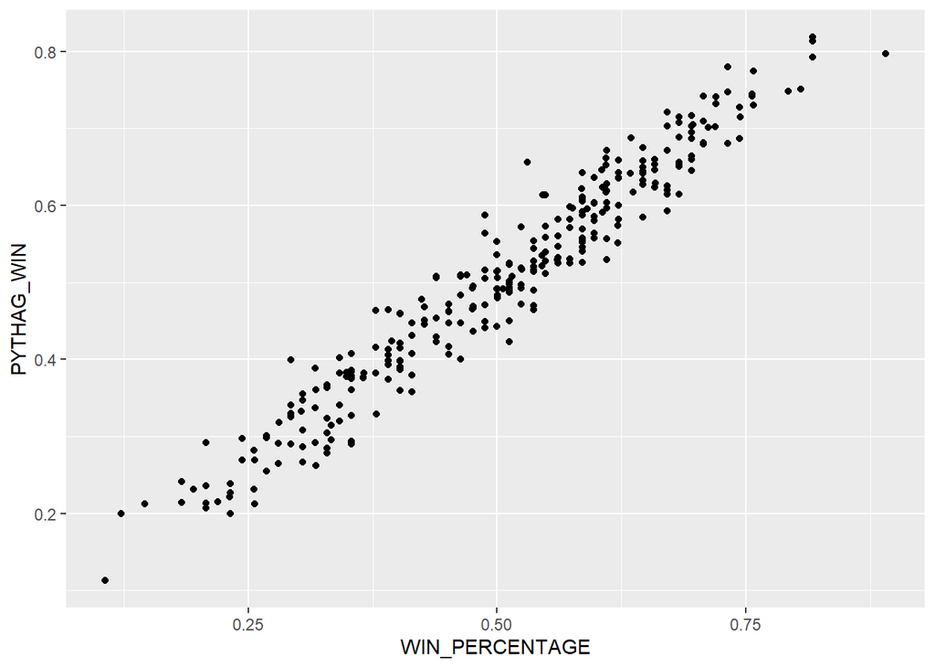

```r
teamStat %>%
  ggplot(mapping = aes(x = WIN_PERCENTAGE, y = PYTHAG_WIN)) +
  geom_point(position = "jitter")
```

**Comments**

- Formula is quite accurate…

### 6.1.1 Time Data

#### 6.1.1.1 Time ~ Median 3PAr

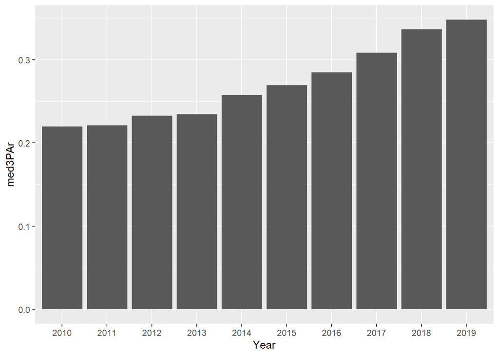

```r
teamStat %>%
  group_by(Year) %>%
  summarize(med3PAr = median(X3PAr)) %>%
  ggplot(mapping = aes(x = Year, y = med3PAr)) +
  geom_bar(stat = "identity")
```

**Comments**

- Year over year, more shots keep coming from three point range
- In 2019, 3PA rate is nearly 35%!

#### 6.1.1.2 Time ~ Median 3PA

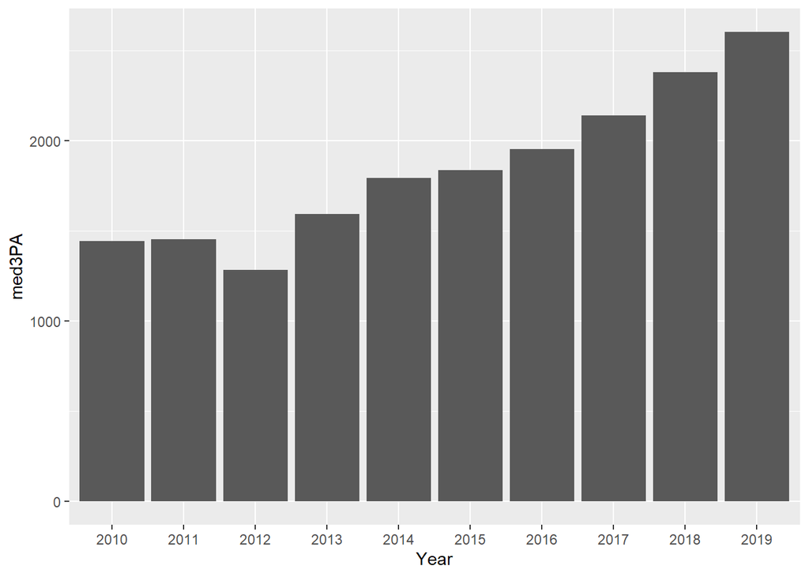

```r
teamStat %>%
  group_by(Year) %>%
  summarize(med3PA = median(X3PA)) %>%
  ggplot(mapping = aes(x = Year, y = med3PA)) +
  geom_bar(stat = "identity")
```

**Comments**

- Clear increase in 3PA over the past ten years

#### 6.1.1.3 Time ~ Median 3P

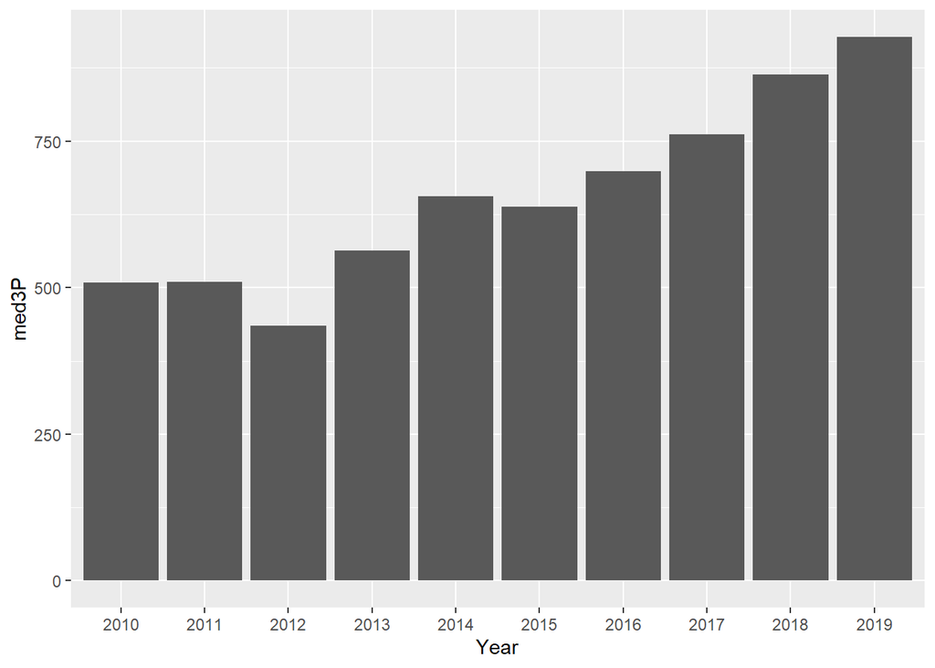

```r
teamStat %>%
  group_by(Year) %>%
  summarize(med3P = median(X3P)) %>%
  ggplot(mapping = aes(x = Year, y = med3P)) +
  geom_bar(stat="identity")
```

**Comments**

- Follows a very similar pattern

#### 6.1.1.4 Time ~ Median Pace

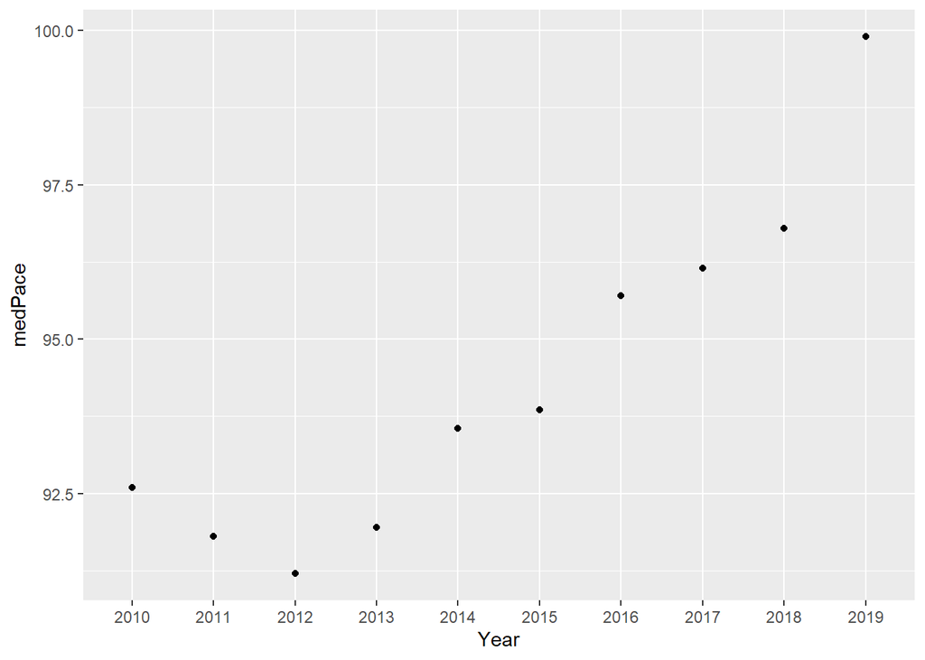

```r
teamStat %>%
  group_by(Year) %>%
  summarize(medPace = median(Pace)) %>%
  ggplot(mapping = aes(x = Year, y = medPace)) +
  geom_point()
```

**Comments**

- Pace has significantly increased in the past 8 years

#### 6.1.1.5 Time ~ Mean Wins

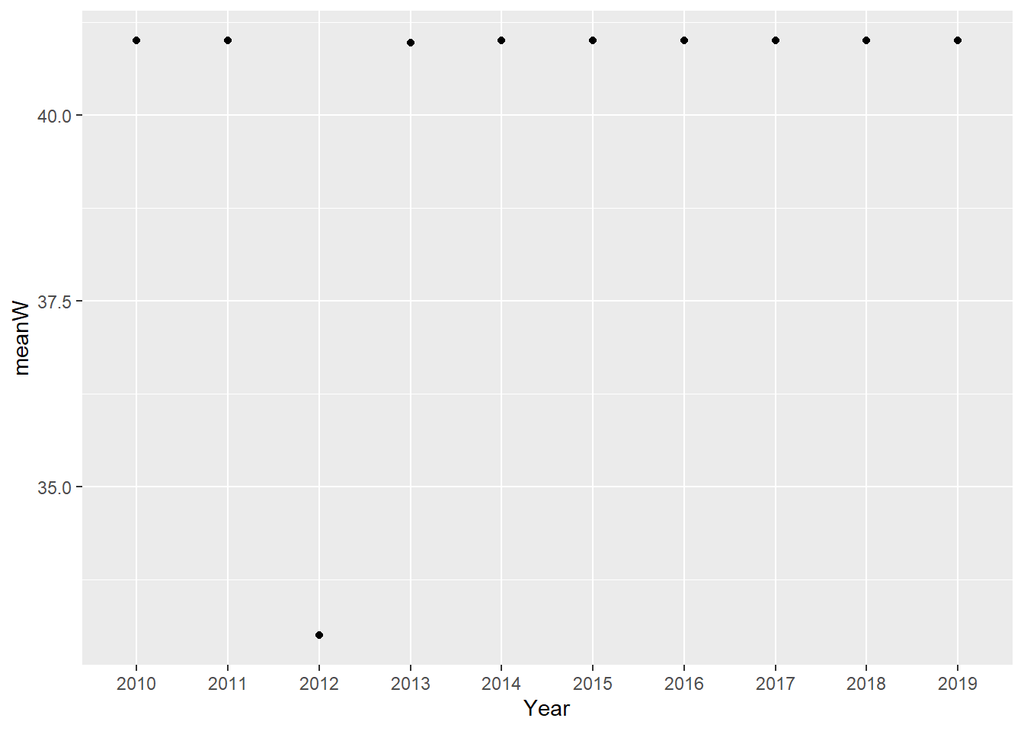

```r
teamStat %>%
  group_by(Year) %>%
  summarize(meanW = mean(W)) %>%
  ggplot(mapping = aes(x = Year, y = meanW)) +
  geom_point()
```

**Comments**

- 2012 season was shortened due to lockout.
  - Ergo lower averages for the year

### 6.1.2 Team Effective FG% versus Win%

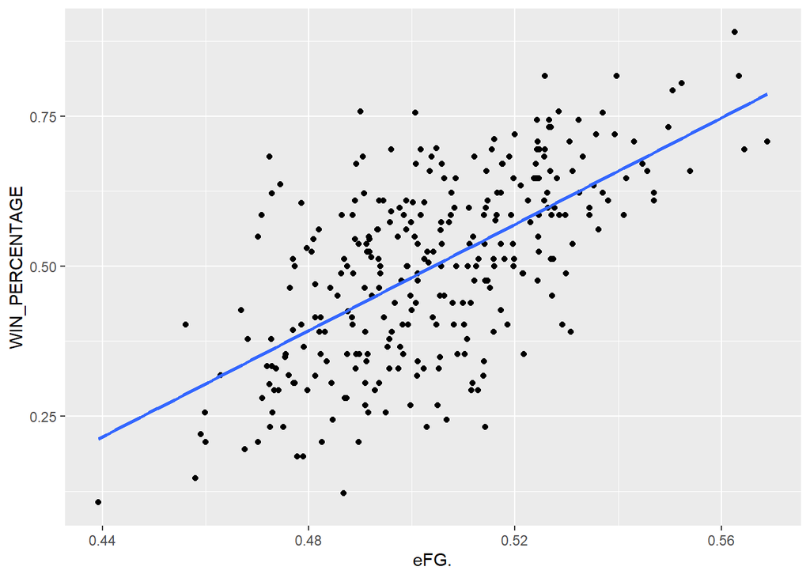

```r
teamStat %>%
  group_by(Team) %>%
  ggplot(mapping = aes(x = eFG., y = WIN_PERCENTAGE)) +
  geom_point() +
  geom_smooth(method = lm, se = FALSE)
```

**Comments**

### 6.1.3 3P Shooting

#### 6.1.3.1 3PA vs. 3P Made

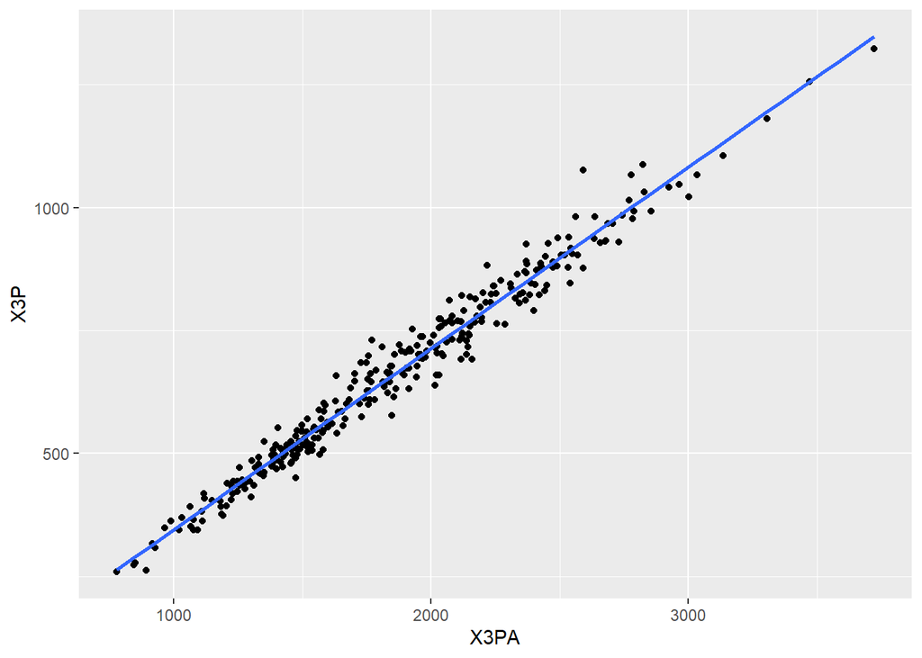

```r
teamStat %>%
ggplot(mapping = aes(x = X3PA, y = X3P)) +
geom_point() +
geom_smooth(method = lm, se = FALSE)
```

**Comments**

- Clear linear relationship between 3P taken and 3P made
- Ergo, if a team wants to make more 3’s, they need to take more 3’s

#### 6.1.3.2 3P Attempted ~ Win%

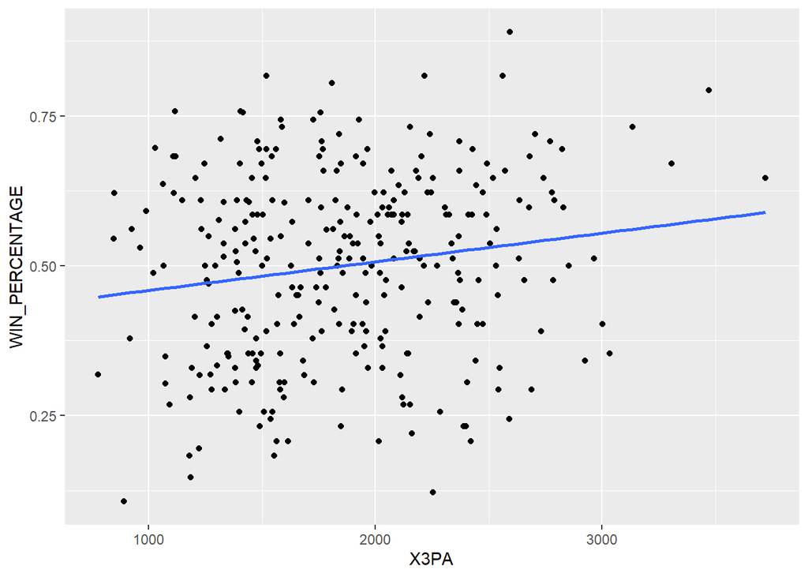

```r
teamStat %>%
  group_by(Team) %>%
  ggplot(mapping = aes(x = X3PA, y = WIN_PERCENTAGE)) +
  geom_point() +
  geom_smooth(method = lm, se = FALSE)
```

#### 6.1.3.3 3P Made ~ Win%

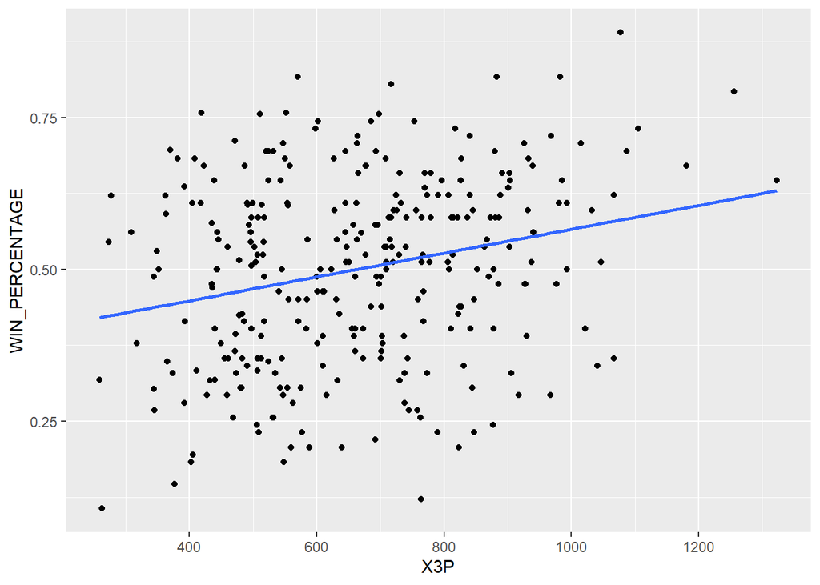

```r
teamStat %>%
  group_by(Team) %>%
  ggplot(mapping = aes(x = X3P, y = WIN_PERCENTAGE)) +
  geom_point() +
  geom_smooth(method = lm, se = FALSE)
```

#### 6.1.3.4 3P Percentage ~ Win%

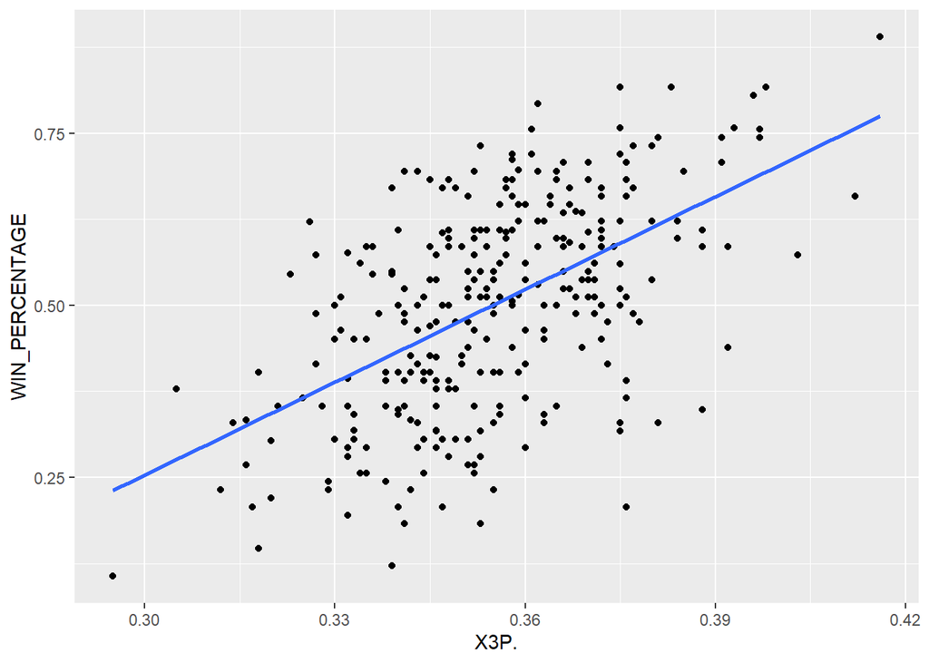

```r
teamStat %>%
  group_by(Team) %>%
  ggplot(mapping = aes(x = X3P., y = WIN_PERCENTAGE)) +
  geom_point() +
  geom_smooth(method = lm, se = FALSE)
```

### 6.1.4 2P Shooting

#### 6.1.4.1 2P Attempted ~ Win%

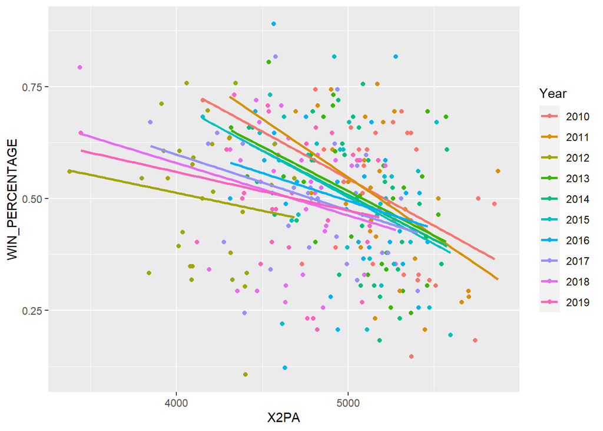

```r
teamStat %>%
  group_by(Team) %>%
  ggplot(mapping = aes(x = X2PA, y = WIN_PERCENTAGE, color = Year)) +
  geom_point() +
  geom_smooth(method = lm, se = FALSE)
```

**Comments**

- Beyond 5,000 seems to show the most noticeable negative relationship

#### 6.1.4.2 2P Made ~ Win%

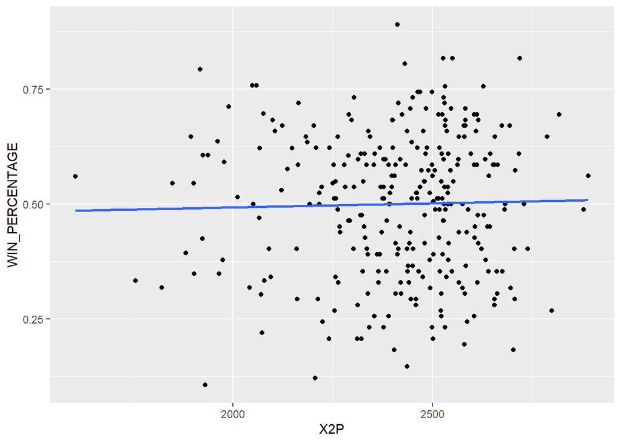

```r
teamStat %>%
  group_by(Team) %>%
  ggplot(mapping = aes(x = X2P, y = WIN_PERCENTAGE)) +
  geom_point() +
  geom_smooth(method = lm, se = FALSE)
```

#### 6.1.4.3 2P Percentage ~ Win%

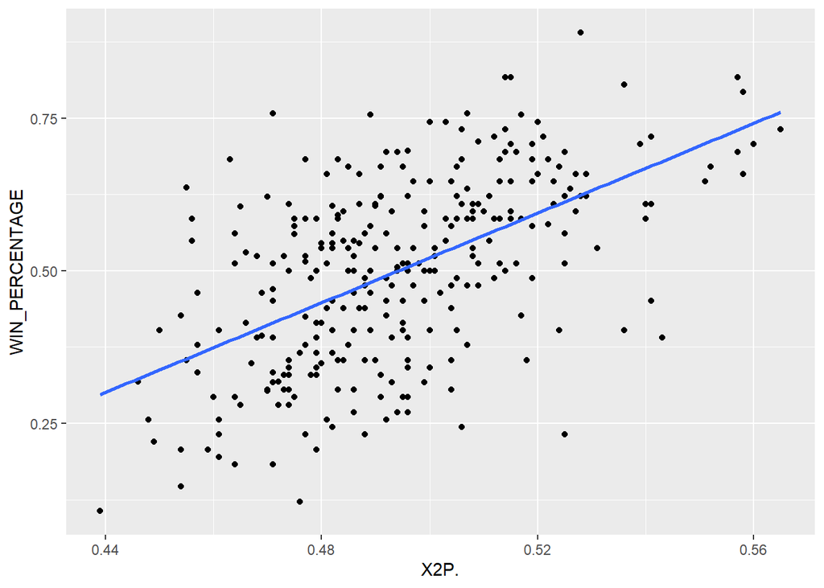

```r
teamStat %>%
  group_by(Team) %>%
  ggplot(mapping = aes(x = X2P., y = WIN_PERCENTAGE)) +
  geom_point() +
  geom_smooth(method = lm, se = FALSE)
```

**Comments**

- Supports the idea of only taking high percentage 2P shots

### 6.1.5 Free Throw Shooting

#### 6.1.5.1 FT Attempted ~ Predicted Wins

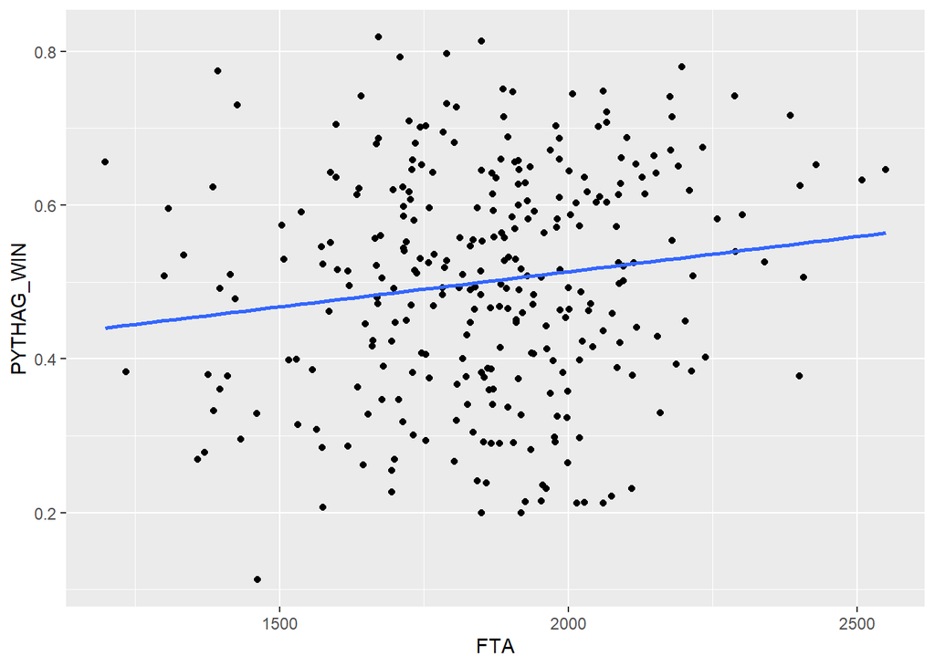

```r
teamStat %>%
  group_by(Team) %>%
  ggplot(mapping = aes(x = FTA, y = PYTHAG_WIN)) +
  geom_point() +
  geom_smooth(method = lm, se = FALSE)
```

#### 6.1.5.2 FT Made ~ Predicted Wins

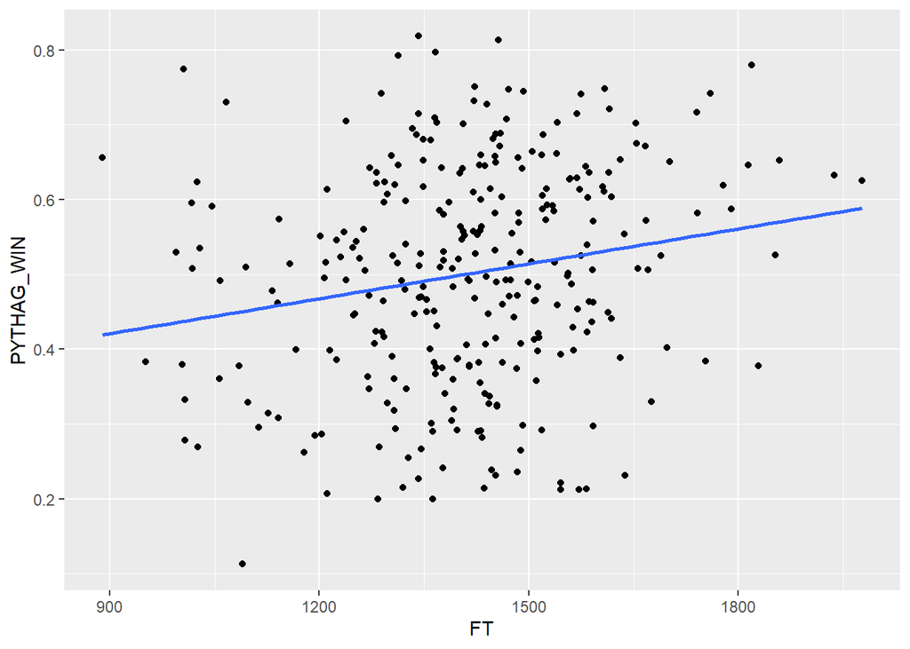

```r
teamStat %>%
  group_by(Team) %>%
  ggplot(mapping = aes(x = FT, y = PYTHAG_WIN)) +
  geom_point() +
  geom_smooth(method = lm, se = FALSE)
```

#### 6.1.5.3 FT Percentage ~ Predicted Wins

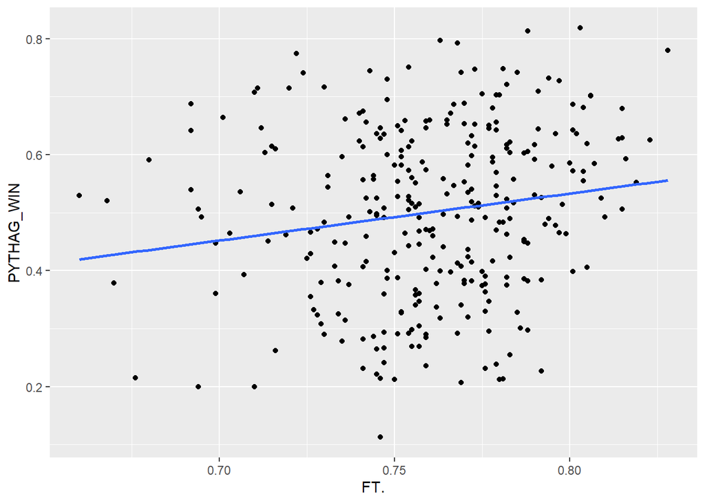

```r
teamStat %>%
  group_by(Team) %>%
  ggplot(mapping = aes(x = FT., y = PYTHAG_WIN)) +
  geom_point() +
  geom_smooth(method = lm, se = FALSE)
```

**Comments**

- Free throw shooting doesn’t seem to have much of an impact on predicted winning

### 6.1.6 Pace

#### 6.1.6.1 Pace ~ Win%

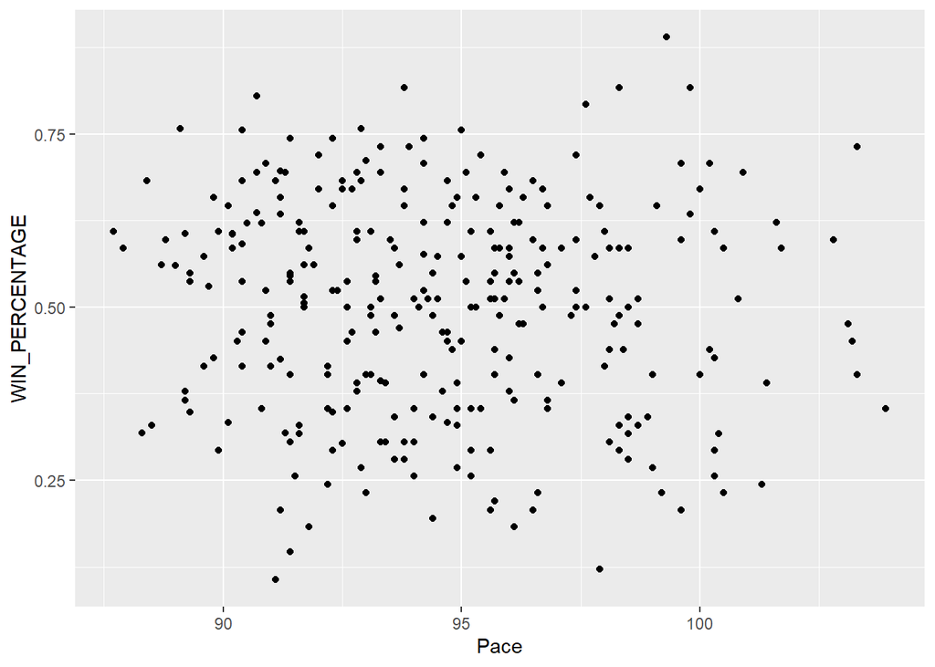

```r
teamStat %>%
  ggplot(mapping = aes(x = Pace, y = WIN_PERCENTAGE)) +
  geom_point()
```

#### 6.1.6.2 Pace ~ Wins

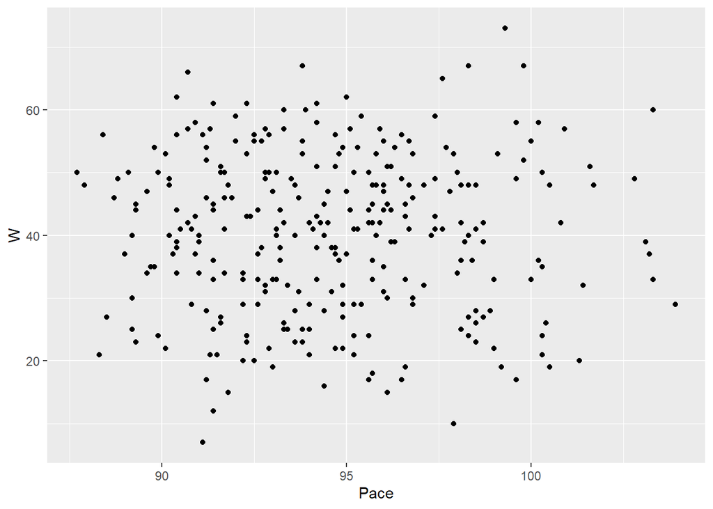

```r
teamStat %>%
  ggplot(mapping = aes(x = Pace, y = W)) +
  geom_point()
```

#### 6.1.6.3 Pace ~ Predicted Win%

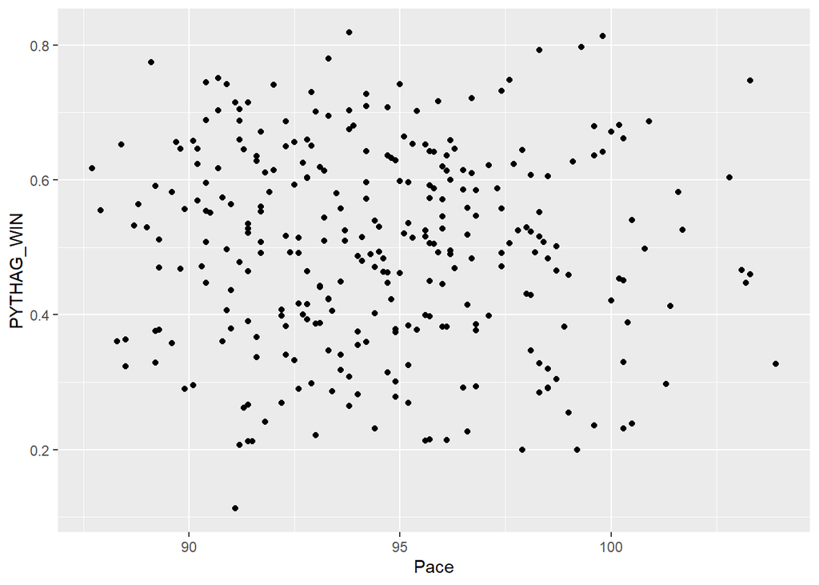

```r
teamStat %>%
  ggplot(mapping = aes(x = Pace, y = PYTHAG_WIN)) +
  geom_point()
```

# 7 Detailed EDA

**Questions**

- Top 10 teams in 3’s attempted? 2’s?
  - Where did these teams end up in the playoff picture?
- How many 3’s should a team attempt to maximize their chances at making the playoffs?
  - Might be better to include this in the statistical EDA

## 7.1 Top 10 teams in 3PA and 2PA

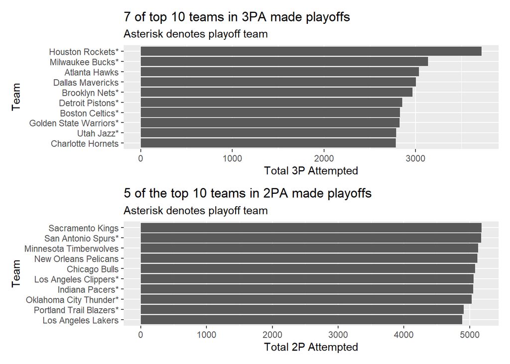

```r
topTenOne <- teamStat %>%
  filter(Year == 2019) %>%
  select(Team, X3PA) %>%
  top_n(n = 10) %>%
  # arrange(desc(X3PA))
  ggplot(mapping = aes(x = reorder(Team, X3PA), y = X3PA)) +
  geom_bar(stat = "identity") +
  coord_flip() +
  labs(title = "7 of top 10 teams in 3PA made playoffs", x = "Team", y = "Total 3P Attempted", subtitle = "Asterisk denotes playoff team") # Asterisk denotes playoff team

topTenTwo <- teamStat %>%
  filter(Year == 2019) %>%
  select(Team, X2PA) %>%
  top_n(n = 10) %>%
  # arrange(desc(X3PA))
  ggplot(mapping = aes(x = reorder(Team, X2PA), y = X2PA)) +
  geom_bar(stat = "identity") +
  coord_flip() +
  labs(title = "5 of the top 10 teams in 2PA made playoffs", x = "Team", y = "Total 2P Attempted", subtitle = "Asterisk denotes playoff team") # Asterisk denotes playoff team

topTenOne / topTenTwo
```

**Comments**

- 7 of 10 teams in top ten 3PA made the playoffs
- Only 5 of 10 in top ten 2PA made playoffs
- Data only covers the 2018-2019 season…
  - Probably can’t use the graph for that reason, but still interesting

## 7.2 Top 10 Teams in FGA

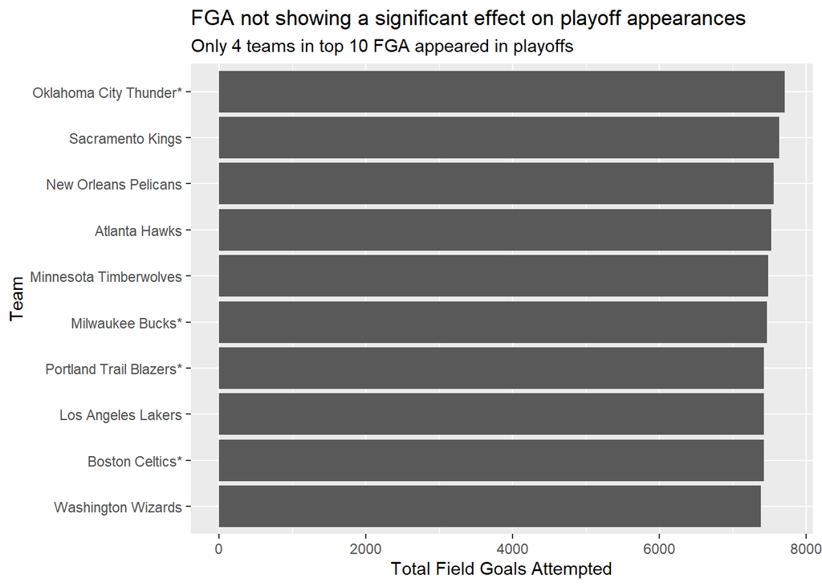

```r
topTwenty <- teamStat %>%
  filter(Year == 2019) %>%
  select(Team, FGA) %>%
  top_n(n = 10) %>%
  # arrange(desc(FGA))
  ggplot(mapping = aes(x = reorder(Team, FGA), y = FGA)) +
  geom_bar(stat = "identity") +
  coord_flip() +
  labs(title = "FGA not showing a significant effect on playoff appearances", x = "Team", y = "Total Field Goals Attempted", subtitle = "Only 4 teams in top 10 FGA appeared in playoffs") # Asterisk denotes playoff team
topTwenty
```

**Comments**

## 7.3 3P vs 2P ~ Predicted Win %

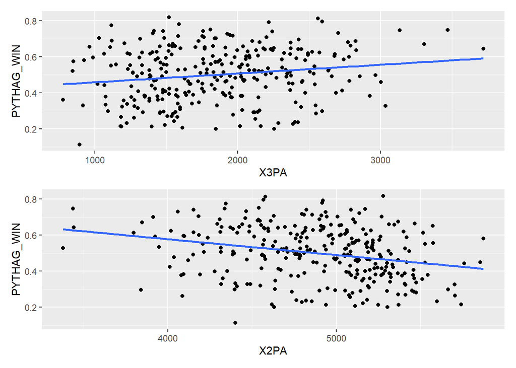

```r
x3pa_pythag <- teamStat %>%
  group_by(Team) %>%
  ggplot(mapping = aes(x = X3PA, y = PYTHAG_WIN)) +
  geom_point() +
  geom_smooth(method = lm, se = FALSE)

x2pa_pythag <- teamStat %>%
  group_by(Team) %>%
  ggplot(mapping = aes(x = X2PA, y = PYTHAG_WIN)) +
  geom_point() +
  geom_smooth(method = lm, se = FALSE)

x3pa_pythag / x2pa_pythag
```

**Comments**

- Not exactly what I was expecting

# 8 Statistical EDA

## 8.1 Initial Regression with Playoffs

```r
playoffProb <- lm(teamStat$Playoffs ~ teamStat$X3PA + teamStat$X3P + teamStat$X2PA + teamStat$X2P + teamStat$Pace + teamStat$WIN_PERCENTAGE)
summary(playoffProb)
```

```
##
## Call:
## lm(formula = teamStat$Playoffs ~ teamStat$X3PA + teamStat$X3P +
##     teamStat$X2PA + teamStat$X2P + teamStat$Pace + teamStat$WIN_PERCENTAGE)
##
## Residuals:
##      Min       1Q   Median       3Q      Max
## -0.73284 -0.18793  0.01701  0.21772  0.58777
##
## Coefficients:
##                           Estimate Std. Error t value Pr(>|t|)
## (Intercept)             -0.6374573  0.7668095  -0.831   0.4065
## teamStat$X3PA            0.0004107  0.0002283   1.799   0.0731 .
## teamStat$X3P            -0.0010563  0.0006063  -1.742   0.0825 .
## teamStat$X2PA            0.0001788  0.0001266   1.412   0.1589
## teamStat$X2P            -0.0004001  0.0002546  -1.572   0.1171
## teamStat$Pace           -0.0026053  0.0089184  -0.292   0.7704
## teamStat$WIN_PERCENTAGE  2.8885755  0.1652911  17.476   <2e-16 ***
## ---
## Signif. codes:  0 '***' 0.001 '**' 0.01 '*' 0.05 '.' 0.1 ' ' 1
##
## Residual standard error: 0.2911 on 293 degrees of freedom
## Multiple R-squared:  0.6675, Adjusted R-squared:  0.6607
## F-statistic: 98.04 on 6 and 293 DF,  p-value: < 2.2e-16
```

**Comments**

- Need to remove non-significant variables

## 8.2 Modified Regression with Playoffs

```r
# Pythag_win multiplied by 82 to get predicted NUMBER of wins
playoffProb <- lm(teamStat$Playoffs ~ teamStat$X3PA + teamStat$X3P + teamStat$WIN_PERCENTAGE)
summary(playoffProb)
```

```
##
## Call:
## lm(formula = teamStat$Playoffs ~ teamStat$X3PA + teamStat$X3P +
##     teamStat$WIN_PERCENTAGE)
##
## Residuals:
##      Min       1Q   Median       3Q      Max
## -0.73160 -0.21001  0.01176  0.21996  0.59495
##
## Coefficients:
##                           Estimate Std. Error t value Pr(>|t|)
## (Intercept)             -0.8266286  0.0884228  -9.349   <2e-16 ***
## teamStat$X3PA            0.0003696  0.0002226   1.660   0.0979 .
## teamStat$X3P            -0.0010797  0.0006067  -1.780   0.0762 .
## teamStat$WIN_PERCENTAGE  2.7756391  0.1311482  21.164   <2e-16 ***
## ---
## Signif. codes:  0 '***' 0.001 '**' 0.01 '*' 0.05 '.' 0.1 ' ' 1
##
## Residual standard error: 0.2915 on 296 degrees of freedom
## Multiple R-squared:  0.6631, Adjusted R-squared:  0.6597
## F-statistic: 194.2 on 3 and 296 DF,  p-value: < 2.2e-16
```

**Comments**

## 8.3 Initial Regression with shooting & win ratio

```r
winPerc <- lm(teamStat$WIN_PERCENTAGE ~ teamStat$X3PA + teamStat$X3P + teamStat$X2PA + teamStat$X2P + teamStat$Pace)
summary(winPerc)
```

```
##
## Call:
## lm(formula = teamStat$WIN_PERCENTAGE ~ teamStat$X3PA + teamStat$X3P +
##     teamStat$X2PA + teamStat$X2P + teamStat$Pace)
##
## Residuals:
##       Min        1Q    Median        3Q       Max
## -0.224046 -0.069538  0.003163  0.067587  0.276154
##
## Coefficients:
##                 Estimate Std. Error t value Pr(>|t|)
## (Intercept)    2.317e+00  2.344e-01   9.882  < 2e-16 ***
## teamStat$X3PA -5.176e-04  7.468e-05  -6.931 2.65e-11 ***
## teamStat$X3P   1.492e-03  1.954e-04   7.636 3.16e-13 ***
## teamStat$X2PA -4.385e-04  3.661e-05 -11.977  < 2e-16 ***
## teamStat$X2P   8.869e-04  7.345e-05  12.075  < 2e-16 ***
## teamStat$Pace -1.944e-02  2.935e-03  -6.624 1.66e-10 ***
## ---
## Signif. codes:  0 '***' 0.001 '**' 0.01 '*' 0.05 '.' 0.1 ' ' 1
##
## Residual standard error: 0.1027 on 294 degrees of freedom
## Multiple R-squared:  0.5609, Adjusted R-squared:  0.5534
## F-statistic:  75.1 on 5 and 294 DF,  p-value: < 2.2e-16
```

**Comments**

## 8.4 Initial regression with efficiency and win ratio

```r
effWin <- lm(teamStat$WIN_PERCENTAGE ~ teamStat$X3P. + teamStat$X2P. + teamStat$FT.)
summary(effWin)
```

```
##
## Call:
## lm(formula = teamStat$WIN_PERCENTAGE ~ teamStat$X3P. + teamStat$X2P. +
##     teamStat$FT.)
##
## Residuals:
##       Min        1Q    Median        3Q       Max
## -0.272480 -0.079290  0.001512  0.084168  0.296211
##
## Coefficients:
##               Estimate Std. Error t value Pr(>|t|)
## (Intercept)    -2.0696     0.2180  -9.493  < 2e-16 ***
## teamStat$X3P.   3.1575     0.4008   7.878 6.37e-14 ***
## teamStat$X2P.   2.6946     0.3133   8.600 4.72e-16 ***
## teamStat$FT.    0.1544     0.2339   0.660     0.51
## ---
## Signif. codes:  0 '***' 0.001 '**' 0.01 '*' 0.05 '.' 0.1 ' ' 1
##
## Residual standard error: 0.1161 on 296 degrees of freedom
## Multiple R-squared:  0.4352, Adjusted R-squared:  0.4295
## F-statistic: 76.04 on 3 and 296 DF,  p-value: < 2.2e-16
```

**Comments**

- Free throw effiency not statistically significant
- I wonder if defensive efficiency ratings would account for roughly 40% variation

## 8.5 Modified Regression

```r
effWin2 <- lm(teamStat$WIN_PERCENTAGE ~ teamStat$X3P. + teamStat$X2P.)
summary(effWin2)
```

```
##
## Call:
## lm(formula = teamStat$WIN_PERCENTAGE ~ teamStat$X3P. + teamStat$X2P.)
##
## Residuals:
##       Min        1Q    Median        3Q       Max
## -0.277860 -0.077111 -0.000701  0.083915  0.299003
##
## Coefficients:
##               Estimate Std. Error t value Pr(>|t|)
## (Intercept)    -1.9751     0.1643 -12.021  < 2e-16 ***
## teamStat$X3P.   3.2096     0.3925   8.177 8.57e-15 ***
## teamStat$X2P.   2.7034     0.3127   8.645 3.42e-16 ***
## ---
## Signif. codes:  0 '***' 0.001 '**' 0.01 '*' 0.05 '.' 0.1 ' ' 1
##
## Residual standard error: 0.116 on 297 degrees of freedom
## Multiple R-squared:  0.4344, Adjusted R-squared:  0.4306
## F-statistic: 114.1 on 2 and 297 DF,  p-value: < 2.2e-16
```

## 8.6 Correlation Test: 2PA ~ Win Ratio

```r
cor.test(teamStat$X2PA, teamStat$WIN_PERCENTAGE,
         method = "pearson")
```

```
##
##  Pearson's product-moment correlation
##
## data:  teamStat$X2PA and teamStat$WIN_PERCENTAGE
## t = -4.5499, df = 298, p-value = 7.823e-06
## alternative hypothesis: true correlation is not equal to 0
## 95 percent confidence interval:
##  -0.3577784 -0.1458314
## sample estimates:
##        cor
## -0.2548634
```

**Comments**

- We can say with 95% confidence, that the correlation betwee 2P attempted and win percentage will be between -35.78% and -14.58 percent
- Simply put, there is a reliable negative correlation between 2P attempted and win percentage

# 9 Professional Visuals

## 9.1 Quantity and Efficiency ~ 3P

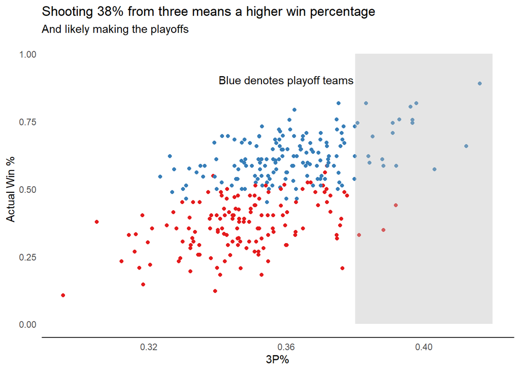

```r
x3p._pythag <- teamStat %>%
  group_by(Team) %>%
  ggplot(mapping = aes(x = X3P., y = WIN_PERCENTAGE, color = Playoffs)) +
  geom_point(position = "jitter") +
  theme_classic() +
  scale_color_brewer(palette = "Set1") +
  theme(axis.ticks = element_blank(),
        axis.line.y = element_blank(),
        legend.position = "none") +
  labs(title = "Shooting 38% from three means a higher win percentage", subtitle = "And likely making the playoffs", x = "3P%", y = "Actual Win %") +
  annotate(geom = "rect", xmin = 0.38, xmax = 0.42, ymin = 0, ymax = 1, fill = "gray", alpha = 0.4) +
  annotate(geom = "text", x = 0.36, y = 0.905, label = "Blue denotes playoff teams")

x3p._pythag
```

```r
ggsave(filename = "finding1.jpg", plot = x3p._pythag, width = 9)
```

## 9.2 2PA ~ Win Ratio by Year

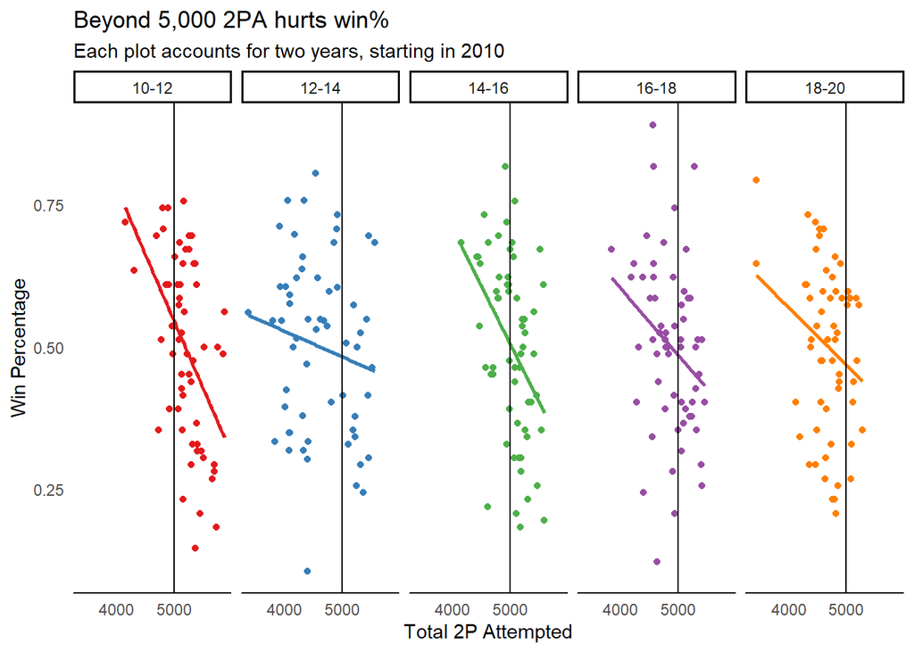

```r
memo2 <- teamStat %>%
  mutate(Year = fct_recode(Year, `10-12` = "2010", `10-12` = "2011", `12-14` = "2012", `12-14` = "2013", `14-16` = "2014", `14-16` = "2015", `16-18` = "2016", `16-18` = "2017", `18-20` = "2018", `18-20` = "2019")) %>%
  group_by(Team, Year) %>%
  ggplot(mapping = aes(x = X2PA, y = WIN_PERCENTAGE, color = Year)) +
  geom_point() +
  geom_smooth(method = lm, se = FALSE) +
  theme_classic() +
  theme(axis.ticks.x = element_blank(), axis.line.y = element_blank(), axis.ticks.y = element_blank(), legend.position = "none") +
  scale_color_brewer(palette = "Set1") +
  labs(title = "Beyond 5,000 2PA hurts win%", subtitle = "Each plot accounts for two years, starting in 2010", x = "Total 2P Attempted", y = "Win Percentage") +
  geom_vline(xintercept = 5000) +
  facet_grid(~ Year)
memo2
```

```r
ggsave(filename = "finding2.jpg", plot = memo2, width = 9)
```